# Analysis on Exponential Distribution and CLT in R

Thiloshon Nagarajah

4/20/2017

## Overview

In this analysis i will investigate the exponential distribution in R and compare it with the Central Limit Theorem. The exponential distribution can be simulated in R with rexp(n, lambda) where lambda is the rate parameter. The mean of exponential distribution is 1/lambda and the standard deviation is also 1/lambda. I have set lambda = 0.2 for all of the simulations.

```r
set.seed(1)
library(ggplot2)
expmns = NULL
```

Creating a distribution of averages of 40 exponentials of size 1000

```r
for (i in 1 : 1000) expmns = c(expmns, mean(rexp(40,0.2)))
```

Plotting the histogram of the distribution

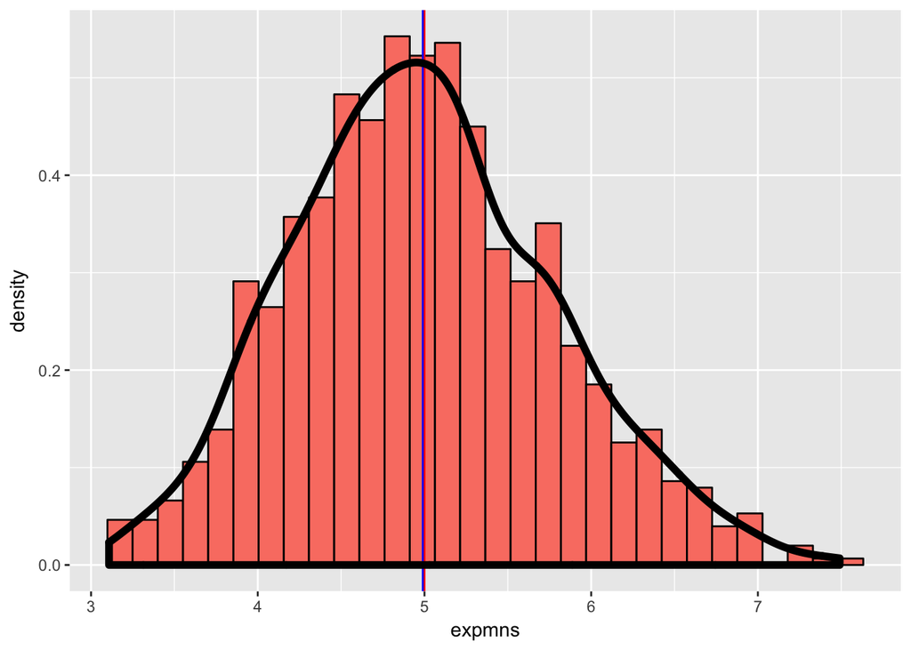

```r
g <- ggplot(as.data.frame(expmns), aes(x = expmns))
g <- g + geom_histogram(fill = "salmon", aes(y = ..density..), colour = "black")
g <- g + geom_vline(xintercept = 5, colour="red")+ geom_vline(xintercept = mean(expmns), colour = "blue")
g <- g + geom_density(size = 2)

g
```

## 1. Show the sample mean and compare it to the theoretical mean of the distribution.

The theoretical mean is drawn as a vertical line in red and the sample mean is drawn in blue in the ablove plot. But the lines are overlapping as both values are pretty much same. To be precise lets get the mean of exponential distribution from (1/rate parameter).

```r
1/0.2
```

```
## [1] 5
```

And also get the mean of the generated exponential.

```r
mean(expmns)
```

```
## [1] 4.990025
```

This shows the mean of the sample and theoretical mean are both very much same.

## 2. Show how variable the sample is (via variance) and compare it to the theoretical variance of the distribution.

The theoretical varience of exponential distribution is given by,

```r
((1/0.2)/sqrt(40))^2
```

```
## [1] 0.625
```

whereas the variance of the generated exponential is given by,

```r
var(expmns)
```

```
## [1] 0.6111165
```

We can conclude both varience are very much similar.

## Show that the distribution is approximately normal.

To better analyce the CLT, lets create distribution of a large collection of random exponentials and compare with a plot of distribution of a large collection of averages of 40 exponentials.

Plot of distribution of a large collection of random exponentials

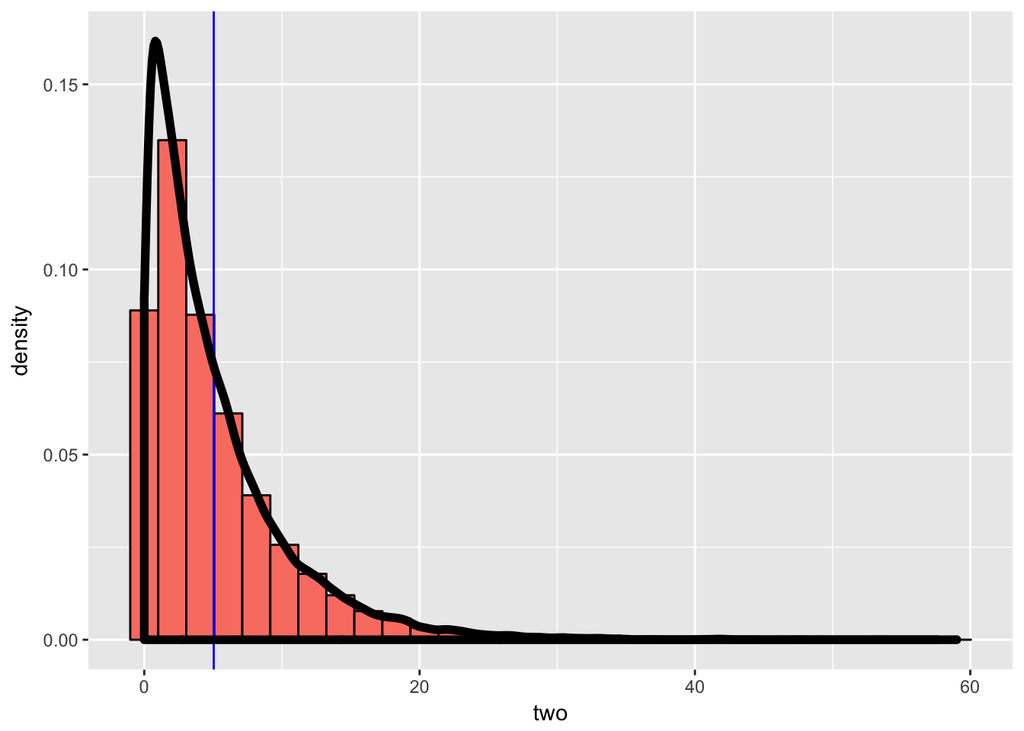

```r
two<-NULL
for (i in 1 : 1000) two = c(two, rexp(40,0.2))

g <- ggplot(as.data.frame(two), aes(x = two))
g <- g + geom_histogram(fill = "salmon", aes(y = ..density..), colour = "black")
g <- g  + geom_vline(xintercept = mean(two), colour = "blue")
g <- g + geom_density(size = 2)
g
```

Plot of distribution of a large collection of averages of 40 exponentials.

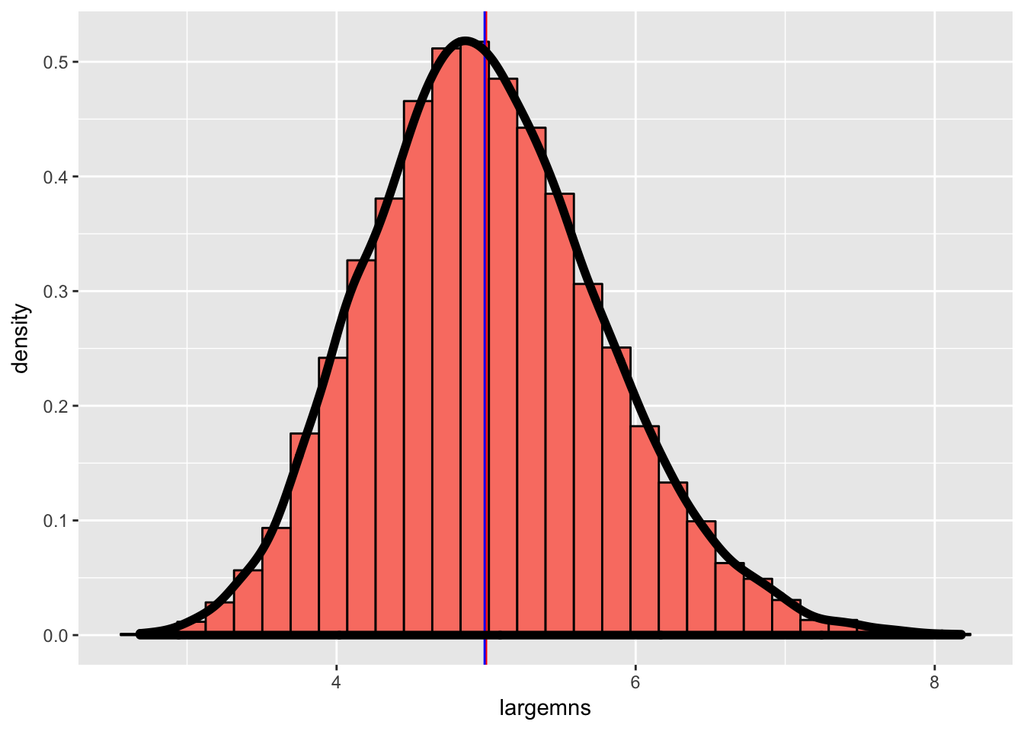

```r
largemns<-NULL
for (i in 1 : 10000) largemns = c(largemns, mean(rexp(40,0.2)))
g <- ggplot(as.data.frame(largemns), aes(x = largemns))
g <- g + geom_histogram(fill = "salmon", aes(y = ..density..), colour = "black")
g <- g + geom_vline(xintercept = 5, colour="red")+ geom_vline(xintercept = mean(expmns), colour = "blue")
g <- g + geom_density(size = 2)

g
```